# Simulation Statistical inference

Overview In the first part I will investigate the exponential distribution in R and compare it with the Central Limit Theorem (CLT). I Should use the knowledge learnt in class to relate the normal and gaussian distributions, using averages of random numbers of thosse distributions. In the second part I will perform a basic inferential data analysis.

# Part 1: Simulation Exercise

For this simulation exercise, we first start loading libraries and initializing variables, setting lambda to 0.2 and n to 40. Then we compute 1000 random exponentials and save it as a vector into dexp variable. Also, we run simulations of the means of 40 exponentials, 1000 times.

```r
library(knitr)
lambda <- 0.2
n <- 40
total <- data.frame(estimator=character(), theoretical=numeric(), sample=numeric(), sample_means=numeric())
# 1000 exponentials
dexp <- rexp(1000, lambda)
# 1000 simulations of the mean of 40 exponentials
mns = NULL
for (i in 1 : 1000) mns = c(mns, mean(rexp(n, lambda)))
```

With our values computed and stored, we can proceed to compute the mean.

```r
# Compute mean
theorethical_mean <- 1/lambda
sample_mean <- mean(dexp)
sample_means_1000mean <- mean(mns)
new_row <- data.frame("Mean", theorethical_mean, sample_mean, sample_means_1000mean)
names(new_row) <- c("estimator", "theoretical", "sample", "sample_means" )
total <- rbind(total, new_row)
kable(total, caption="Theoretical vs sample mean")
```

| estimator | theoretical | sample | sample_means |
| --- | --- | --- | --- |
| Mean | 5 | 5.062837 | 5.012825 |

We can see that the sample mean is almost near the theoretical mean. But as the number of values increases, the mean gets closer to the asympthotic representing the theorethical mean. The sample means of the means of 1000 simulations, is even closer.

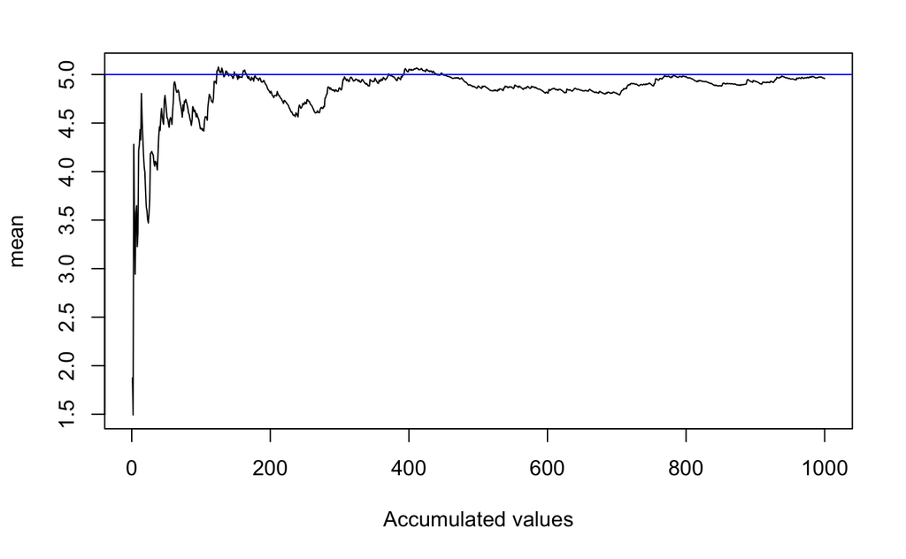

```r
cum <- cumsum(rexp(1000, lambda))/(1:1000)
plot(cum, type="l", xlab = "Accumulated values", ylab = "mean")
abline(h=theorethical_mean, col="blue")
```

```r
theorethical_sd <- 1/lambda
sample_sd <- sd(dexp)
sample_means_1000sd <- sd(mns)
new_row <- data.frame("Standard deviation", theorethical_sd, sample_sd, sample_means_1000sd)
names(new_row) <- c("estimator", "theoretical", "sample", "sample_means")
total <- rbind(total, new_row)


theorethical_var <- theorethical_sd^2
sample_var <- var(dexp)
sample_means_1000var <- var(mns)
new_row <- data.frame("Variance", theorethical_var, sample_var, sample_means_1000var)
names(new_row) <- c("estimator", "theoretical", "sample", "sample_means")
total <- rbind(total, new_row)
kable(total, caption="Theoretical vs sample")
```

| estimator | theoretical | sample | sample_means |
| --- | --- | --- | --- |
| Mean | 5 | 5.062837 | 5.0128246 |
| Standard deviation | 5 | 5.057375 | 0.7893703 |
| Variance | 25 | 25.577038 | 0.6231055 |

```r
hist(dexp,  main = 'rexp(1000, 0.2)')
```

[output not shown]

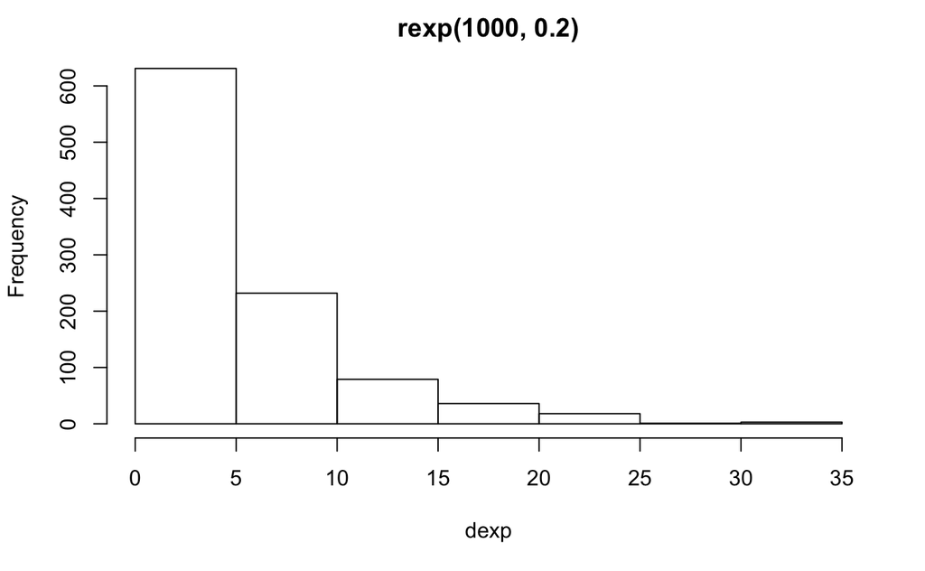

```r
hist(dexp,  main = 'rexp(1000, 0.2)', pin=1)
```

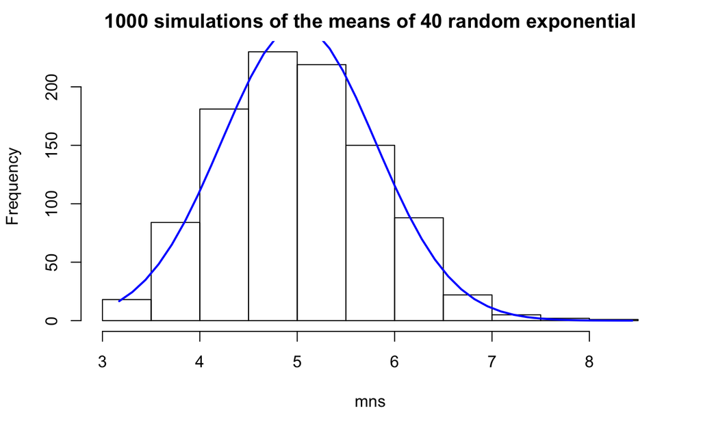

```r
h <- hist(mns, main = '1000 simulations of the means of 40 random exponential')
xfit <- seq(min(mns), max(mns), length = 40)
yfit <- dnorm(xfit, mean = mean(mns), sd = sd(mns))
yfit <- yfit * diff(h$mids[1:2]) * length(mns)
lines(xfit, yfit, col = "blue", lwd = 2)
```